# Regression

Justin Hardy & Benji Frenkel

## Description

Linear Regression is a concept in statistics that is powerful in the context of machine learning. Its goal is to determine how much we can expect a given y-value to change for every change in the x-value. Within the R language, we can build Linear Regression Models that will not only determine this linear relationship between two (or more) variables in a given data set, but also provide us with various useful information to help us gauge how strong of a relationship these variables have by providing us with useful coefficients.

The main strength of Linear Regression is that it’s both incredibly simple and powerful. This is especially true for data sets that follow a linear pattern.

The main weakness of Linear Regression is that it has considerably high bias, at the expense of having low variance. This is purely due to the fact that it tries to fit the data to a linear shape, which can become problematic when the data being used doesn’t always follow a linear shape.

In this assignment, we’ll explore linear regression in detail. I’ve picked out a data set online that consists of web data collected on Online Shoppers for, what is presumably, a retail store.

## Modeling

### Data Set Setup

Starting out, we’ll load our data set into R.

```r
# data set input
ShopperIntentions <- read.csv("online_shoppers_intention.csv")
```

I’ll go ahead and create a factor for various qualitative values, that I feel like I’ll want to use later in the assignment.

```r
# data set cleanup
ShopperIntentions$Month <- factor(ShopperIntentions$Month, levels=c("Jan", "Feb", "Mar", "Apr", "May", "June", "Jul", "Aug", "Sep", "Oct", "Nov", "Dec"))
ShopperIntentions$VisitorType <- factor(ShopperIntentions$VisitorType, levels=c("Returning_Visitor", "New_Visitor", "Other"))
ShopperIntentions$Weekend <- factor(ShopperIntentions$Weekend)
```

### Dividing Into Train / Test

Next, we’ll split the data into train & test as per the machine learning process.

```r
# train/test division
i <- sample(1:nrow(ShopperIntentions), nrow(ShopperIntentions)*0.8, replace=FALSE)
train <- ShopperIntentions[i,]
test <- ShopperIntentions[-i,]
```

### Data Exploration / Graphing

We’ll be exploring the data within our train data set, which makes up 80% of the shopper intentions data set. The following are various details/statistics about the data set itself:

#### Rows / Columns Info:

```
## 'data.frame':    9864 obs. of  18 variables:
##  $ Administrative         : int  0 0 0 1 0 5 2 0 0 7 ...
##  $ Administrative_Duration: num  0 0 0 9 0 ...
##  $ Informational          : int  0 0 0 0 0 0 0 0 0 0 ...
##  $ Informational_Duration : num  0 0 0 0 0 0 0 0 0 0 ...
##  $ ProductRelated         : int  22 13 32 13 5 234 137 7 3 41 ...
##  $ ProductRelated_Duration: num  662.7 700.7 707.7 858.8 95.5 ...
##  $ BounceRates            : num  0.0114 0 0.025 0.0143 0 ...
##  $ ExitRates              : num  0.0427 0.0154 0.0844 0.0512 0.0133 ...
##  $ PageValues             : num  0 0 0 0 0 ...
##  $ SpecialDay             : num  0.4 0 0 0 0 0 0 0 0 0 ...
##  $ Month                  : Factor w/ 12 levels "Jan","Feb","Mar",..: 5 5 6 11 5 11 11 8 10 12 ...
##  $ OperatingSystems       : int  2 3 2 1 2 2 1 1 3 3 ...
##  $ Browser                : int  2 2 2 1 4 2 1 1 2 2 ...
##  $ Region                 : int  4 1 6 6 1 3 1 1 2 5 ...
##  $ TrafficType            : int  2 4 13 11 3 3 10 5 2 1 ...
##  $ VisitorType            : Factor w/ 3 levels "Returning_Visitor",..: 1 1 1 1 1 1 1 2 2 1 ...
##  $ Weekend                : Factor w/ 2 levels "FALSE","TRUE": 1 1 1 1 1 1 2 1 1 2 ...
##  $ Revenue                : logi  FALSE FALSE FALSE TRUE FALSE TRUE ...
```

#### Sample of First Five Rows:

|  | Administrative | Administrative_Duration | Informational | Informational_Duration | ProductRelated | ProductRelated_Duration | BounceRates | ExitRates | PageValues | SpecialDay | Month | OperatingSystems | Browser | Region | TrafficType | VisitorType | Weekend | Revenue |
| --- | --- | --- | --- | --- | --- | --- | --- | --- | --- | --- | --- | --- | --- | --- | --- | --- | --- | --- |
| 5285 | 0 | 0 | 0 | 0 | 22 | 662.6667 | 0.01136364 | 0.04265152 | 0 | 0.4 | May | 2 | 2 | 4 | 2 | Returning_Visitor | FALSE | FALSE |
| 4482 | 0 | 0 | 0 | 0 | 13 | 700.6667 | 0.00000000 | 0.01538462 | 0 | 0.0 | May | 3 | 2 | 1 | 4 | Returning_Visitor | FALSE | FALSE |
| 6775 | 0 | 0 | 0 | 0 | 32 | 707.7000 | 0.02500000 | 0.08437500 | 0 | 0.0 | June | 2 | 2 | 6 | 13 | Returning_Visitor | FALSE | FALSE |
| 11180 | 1 | 9 | 0 | 0 | 13 | 858.8333 | 0.01428571 | 0.05119048 | 0 | 0.0 | Nov | 1 | 1 | 6 | 11 | Returning_Visitor | FALSE | TRUE |
| 5453 | 0 | 0 | 0 | 0 | 5 | 95.5000 | 0.00000000 | 0.01333333 | 0 | 0.0 | May | 2 | 4 | 1 | 3 | Returning_Visitor | FALSE | FALSE |

#### Sample of Last Five Rows:

|  | Administrative | Administrative_Duration | Informational | Informational_Duration | ProductRelated | ProductRelated_Duration | BounceRates | ExitRates | PageValues | SpecialDay | Month | OperatingSystems | Browser | Region | TrafficType | VisitorType | Weekend | Revenue |
| --- | --- | --- | --- | --- | --- | --- | --- | --- | --- | --- | --- | --- | --- | --- | --- | --- | --- | --- |
| 838 | 5 | 117.8333 | 0 | 0 | 35 | 502.5476 | 0.010256410 | 0.03692308 | 3.148615 | 0 | Mar | 2 | 2 | 2 | 2 | Returning_Visitor | FALSE | TRUE |
| 7356 | 4 | 34.4000 | 0 | 0 | 12 | 189.4333 | 0.000000000 | 0.01428571 | 0.000000 | 0 | Sep | 2 | 10 | 4 | 4 | New_Visitor | FALSE | FALSE |
| 255 | 0 | 0.0000 | 0 | 0 | 2 | 8.0000 | 0.000000000 | 0.10000000 | 0.000000 | 0 | Mar | 2 | 2 | 5 | 1 | Returning_Visitor | TRUE | FALSE |
| 9647 | 7 | 146.7000 | 5 | 195 | 42 | 1717.6667 | 0.001960784 | 0.02998133 | 0.000000 | 0 | Dec | 2 | 2 | 1 | 2 | Returning_Visitor | FALSE | FALSE |
| 8453 | 6 | 112.5000 | 0 | 0 | 86 | 2041.2335 | 0.000387597 | 0.00786268 | 5.911452 | 0 | Nov | 2 | 4 | 1 | 2 | Returning_Visitor | FALSE | TRUE |

#### NA Count:

```
## [1] "Number of NAs: 0"
```

#### General Summary:

```
##  Administrative   Administrative_Duration Informational
##  Min.   : 0.000   Min.   :   0.000        Min.   : 0.000
##  1st Qu.: 0.000   1st Qu.:   0.000        1st Qu.: 0.000
##  Median : 1.000   Median :   9.133        Median : 0.000
##  Mean   : 2.331   Mean   :  80.846        Mean   : 0.512
##  3rd Qu.: 4.000   3rd Qu.:  94.600        3rd Qu.: 0.000
##  Max.   :27.000   Max.   :3398.750        Max.   :24.000
##
##  Informational_Duration ProductRelated   ProductRelated_Duration
##  Min.   :   0.00        Min.   :  0.00   Min.   :    0.0
##  1st Qu.:   0.00        1st Qu.:  7.00   1st Qu.:  183.6
##  Median :   0.00        Median : 18.00   Median :  595.2
##  Mean   :  35.16        Mean   : 31.81   Mean   : 1196.0
##  3rd Qu.:   0.00        3rd Qu.: 38.00   3rd Qu.: 1462.2
##  Max.   :2549.38        Max.   :705.00   Max.   :63973.5
##
##   BounceRates         ExitRates         PageValues        SpecialDay
##  Min.   :0.000000   Min.   :0.00000   Min.   :  0.000   Min.   :0.00000
##  1st Qu.:0.000000   1st Qu.:0.01429   1st Qu.:  0.000   1st Qu.:0.00000
##  Median :0.003103   Median :0.02507   Median :  0.000   Median :0.00000
##  Mean   :0.022327   Mean   :0.04318   Mean   :  5.833   Mean   :0.06215
##  3rd Qu.:0.016791   3rd Qu.:0.05000   3rd Qu.:  0.000   3rd Qu.:0.00000
##  Max.   :0.200000   Max.   :0.20000   Max.   :361.764   Max.   :1.00000
##
##      Month      OperatingSystems    Browser          Region
##  May    :2691   Min.   :1.000    Min.   : 1.00   Min.   :1.000
##  Nov    :2379   1st Qu.:2.000    1st Qu.: 2.00   1st Qu.:1.000
##  Mar    :1542   Median :2.000    Median : 2.00   Median :3.000
##  Dec    :1400   Mean   :2.121    Mean   : 2.35   Mean   :3.133
##  Oct    : 441   3rd Qu.:3.000    3rd Qu.: 2.00   3rd Qu.:4.000
##  Sep    : 359   Max.   :8.000    Max.   :13.00   Max.   :9.000
##  (Other):1052
##   TrafficType                VisitorType    Weekend      Revenue
##  Min.   : 1.000   Returning_Visitor:8440   FALSE:7587   Mode :logical
##  1st Qu.: 2.000   New_Visitor      :1358   TRUE :2277   FALSE:8342
##  Median : 2.000   Other            :  66                TRUE :1522
##  Mean   : 4.084
##  3rd Qu.: 4.000
##  Max.   :20.000
##
```

#### Graphs:

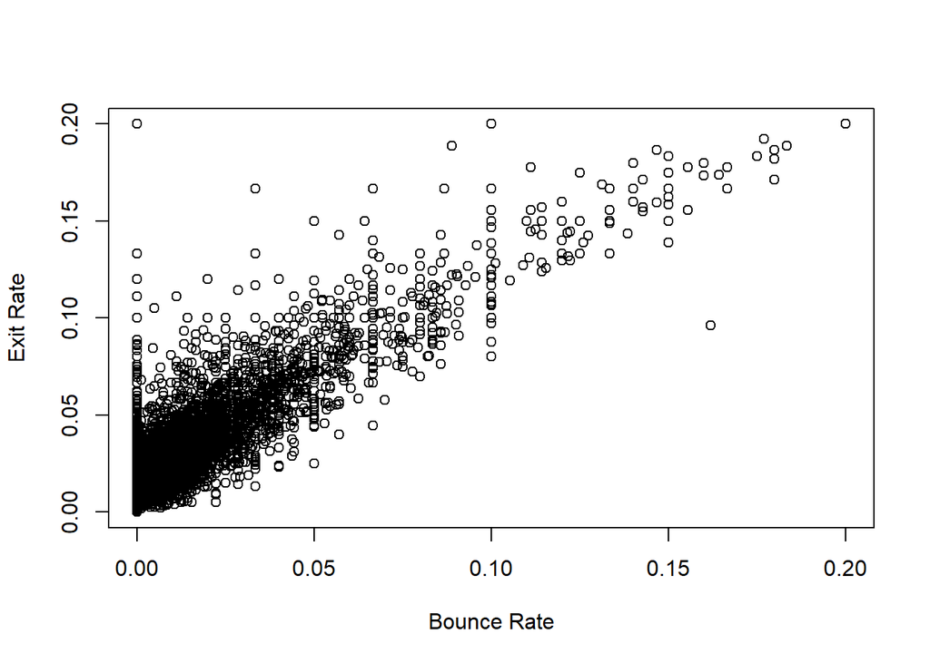

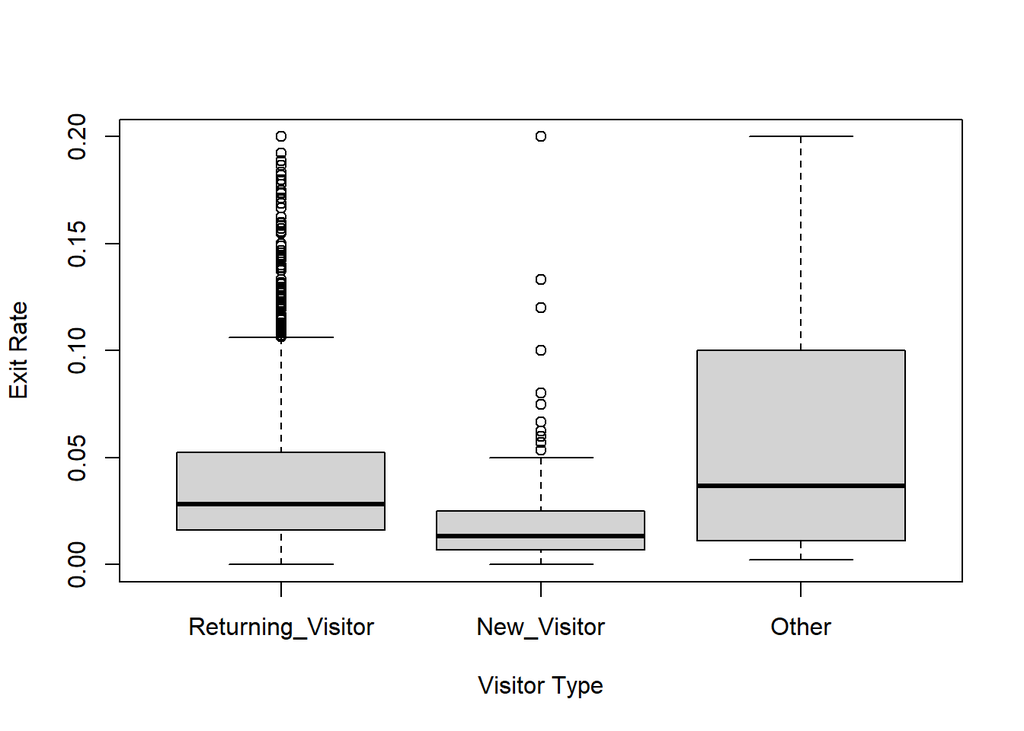

### Simple Linear Regression Model

We’ll start by making a simple linear regression model, where we use the ExitRates column as our target, and the BounceRates column as our predictor. ExitRates simply describes the percentage of paegs that were the last visited, while BounceRates describes the rate at which a users enter the site from that page and also leave from that same page. We’ll then generate a summary of the model, so we can see the residuals and what R thinks about the correlation between the two columns.

```r
# linear regression model
lm_simple <- lm(ExitRates~BounceRates, data=train)

# summary
summary(lm_simple)
```

```
##
## Call:
## lm(formula = ExitRates ~ BounceRates, data = train)
##
## Residuals:
##       Min        1Q    Median        3Q       Max
## -0.074586 -0.012226 -0.005739  0.005819  0.177247
##
## Coefficients:
##              Estimate Std. Error t value Pr(>|t|)
## (Intercept) 0.0227527  0.0002195   103.7   <2e-16 ***
## BounceRates 0.9149332  0.0040968   223.3   <2e-16 ***
## ---
## Signif. codes:  0 '***' 0.001 '**' 0.01 '*' 0.05 '.' 0.1 ' ' 1
##
## Residual standard error: 0.01982 on 9862 degrees of freedom
## Multiple R-squared:  0.8349, Adjusted R-squared:  0.8349
## F-statistic: 4.987e+04 on 1 and 9862 DF,  p-value: < 2.2e-16
```

Now that we’ve created the model and looked at the summary of it, we’ll plot the residuals.

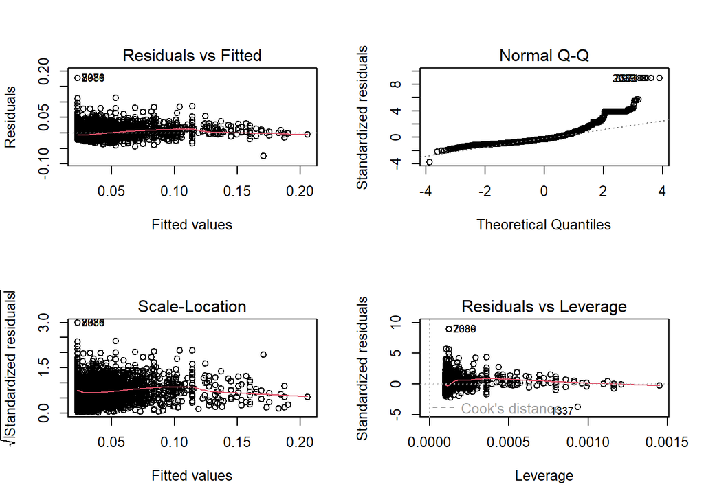

### Multiple Linear Regression Model

The next linear regression model we’ll create will use multiple predictors to predict the same target, ExitRates. We’ll be adding the various Duration column values to the line-up of predictors, and seeing how this improves the model.

```r
# linear regression model
lm_multiple <- lm(ExitRates~BounceRates+Administrative_Duration+Informational_Duration+ProductRelated_Duration, data=train)

# summary
summary(lm_multiple)
```

```
##
## Call:
## lm(formula = ExitRates ~ BounceRates + Administrative_Duration +
##     Informational_Duration + ProductRelated_Duration, data = train)
##
## Residuals:
##       Min        1Q    Median        3Q       Max
## -0.064751 -0.011785 -0.005275  0.006235  0.173675
##
## Coefficients:
##                           Estimate Std. Error t value Pr(>|t|)
## (Intercept)              2.632e-02  2.608e-04 100.950   <2e-16 ***
## BounceRates              8.954e-01  4.065e-03 220.264   <2e-16 ***
## Administrative_Duration -1.417e-05  1.205e-06 -11.764   <2e-16 ***
## Informational_Duration  -1.535e-06  1.449e-06  -1.059     0.29
## ProductRelated_Duration -1.619e-06  1.129e-07 -14.346   <2e-16 ***
## ---
## Signif. codes:  0 '***' 0.001 '**' 0.01 '*' 0.05 '.' 0.1 ' ' 1
##
## Residual standard error: 0.01927 on 9859 degrees of freedom
## Multiple R-squared:  0.844,  Adjusted R-squared:  0.844
## F-statistic: 1.334e+04 on 4 and 9859 DF,  p-value: < 2.2e-16
```

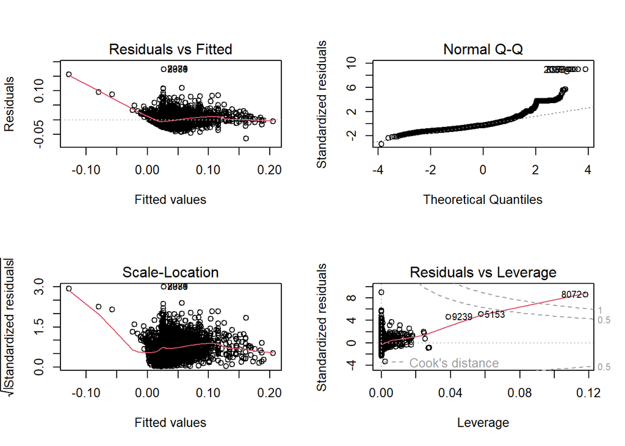

The main change I’d like to note about the residuals is that now, we’re able to not only observe the Cook’s Distance markers, but also now we have a case that lies outside the Cook’s Distance area (marked 8072). Although, for divisons of train/test, this won’t be the case, we can still see outliers that lie close to the Cook’s Distance dashed lines. We can also observe pretty significant dips at the beginning of the Residuals vs Fitted and Scale-Location plots, the latter forming - then breaking - the shape of a parabola. We can interpret this as there not being a linear relationship between the residuals and their fitted values for fitted values less than 0, to which afterwards the line straightens up significantly.

### Final Linear Regression Model

We’ll create one final linear regression model that will include various other columns as predictors. The most notable additions are columns pertaining to special days (holidays/weekends), and whether or not the visitor is new.

```r
# linear regression model
lm_final <- lm(ExitRates~BounceRates+Administrative_Duration+ProductRelated_Duration+PageValues+VisitorType+Weekend+SpecialDay, data=train)

# summary
summary(lm_final)
```

```
##
## Call:
## lm(formula = ExitRates ~ BounceRates + Administrative_Duration +
##     ProductRelated_Duration + PageValues + VisitorType + Weekend +
##     SpecialDay, data = train)
##
## Residuals:
##       Min        1Q    Median        3Q       Max
## -0.065217 -0.011250 -0.004248  0.005516  0.171210
##
## Coefficients:
##                           Estimate Std. Error t value Pr(>|t|)
## (Intercept)              2.879e-02  3.072e-04  93.713  < 2e-16 ***
## BounceRates              8.773e-01  4.028e-03 217.773  < 2e-16 ***
## Administrative_Duration -1.226e-05  1.165e-06 -10.525  < 2e-16 ***
## ProductRelated_Duration -1.867e-06  1.063e-07 -17.566  < 2e-16 ***
## PageValues              -1.492e-04  1.050e-05 -14.210  < 2e-16 ***
## VisitorTypeNew_Visitor  -8.451e-03  5.638e-04 -14.989  < 2e-16 ***
## VisitorTypeOther         5.812e-03  2.323e-03   2.501 0.012385 *
## WeekendTRUE             -1.638e-03  4.490e-04  -3.649 0.000265 ***
## SpecialDay               6.438e-03  9.557e-04   6.736 1.71e-11 ***
## ---
## Signif. codes:  0 '***' 0.001 '**' 0.01 '*' 0.05 '.' 0.1 ' ' 1
##
## Residual standard error: 0.01874 on 9855 degrees of freedom
## Multiple R-squared:  0.8525, Adjusted R-squared:  0.8524
## F-statistic:  7120 on 8 and 9855 DF,  p-value: < 2.2e-16
```

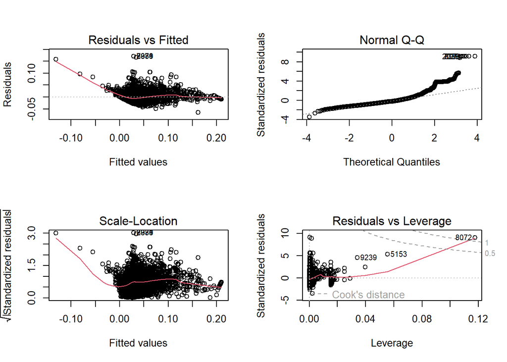

### Results Comparison / Analysis

It should be relatively clear that the third & final linear regression model created is the best model here. Simply because the model utilizes various other predictive factors to improve on the accuracy of the already accurate first/simple model that preceded it. As noted, the first model created was simple, but also incredibly accurate at its base due to the strong correlation between the exit and bounce column. Logically speaking, we can make a number of assumptions about the user’s exit rates given the bounce rate.

Of course, one could argue that the difference in accuracies of the models is almost negligible, therefore the first simple model we created is the best to use. However, I’d argue the difference between the first and last - simple and final - models are notable enough to warrant use of the final model over the simpler one. After all, it’d likely transfer over better outside of the context of our data set.

### Metrics Correlation and MSE

```r
# predictions on test data
pred_simple <- predict(lm_simple, newdata=test)
pred_multiple <- predict(lm_multiple, newdata=test)
pred_final <- predict(lm_final, newdata=test)
```

```
## METRICS:
```

```
## Simple Linear Regression Model:
## Correlation:  0.909965142661834
## MSE:  0.000394221332214538
## RSE:  0.0198550077364512
```

```
## Multiple Linear Regression Model:
## Correlation:  0.916354812859417
## MSE:  0.000367474103394885
## RSE:  0.0191696140648393
```

```
## Final Linear Regression Model:
## Correlation:  0.921088939749632
## MSE:  0.000347532254056763
## RSE:  0.018642216983416
```

Now that we have all of the metrics, let’s compare between the three models!

We can see pretty clearly that we make improvements to our correlation values with each linear model. The correlation was already high to begin with in our linear regression model, as there is a strong base correlation between our exit and bounce rate. However, it’s made clear through the additions of other relevant data as predictors that the model can notably improve its prediction accuracy.

The same explanation can be applied to our MSE & RSE values. As there is a notable decrease in the mean error of the model.